# Phase 1: Exploratory Data Analysis

Rathina Grace Monica

2026-04-29

```r
print("Project Data (LTA Standard Format) Loaded:")
```

```
## [1] "Project Data (LTA Standard Format) Loaded:"
```

```r
head(data)
```

```
##   Latitude Longitude TaxiCount           Timestamp CommuterDemand
## 1 1.374668  103.9520        51 2026-05-02 18:43:03       121.7061
## 2 1.339133  103.8278        45 2026-05-02 18:42:03       131.9819
## 3 1.235035  103.8518        48 2026-05-02 18:41:03       135.4448
## 4 1.271431  103.7705        37 2026-05-02 18:40:03       139.7728
## 5 1.338842  103.7546        42 2026-05-02 18:39:03       141.2435
## 6 1.206283  103.9973        46 2026-05-02 18:38:03       132.3223
```

## 1. Project Overview

As an Adjunct Lecturer, I am developing this module to demonstrate how AI can optimize Singapore’s urban mobility. This phase focuses on Exploratory Data Analysis (EDA) to ensure our dataset is robust for Deep Learning.

## 2. Data Integrity: Missing Values Check

In R, we use the is.na() function to find “empty” cells. This is a critical step because missing data can cause AI models to fail or provide inaccurate predictions.

```r
# Counting if there are any 'empty' cells in our data
missing_counts <- colSums(is.na(data))
print(missing_counts)
```

```
##       Latitude      Longitude      TaxiCount      Timestamp CommuterDemand
##              0              0              0              0              0
```

## 3. Detecting Noise (Outliers)

‘Noise’ refers to data points that are so far away from the average that they might represent errors or highly unusual events. A Boxplot is an effective visual tool for identifying these anomalies in our **Commuter Demand** variable.

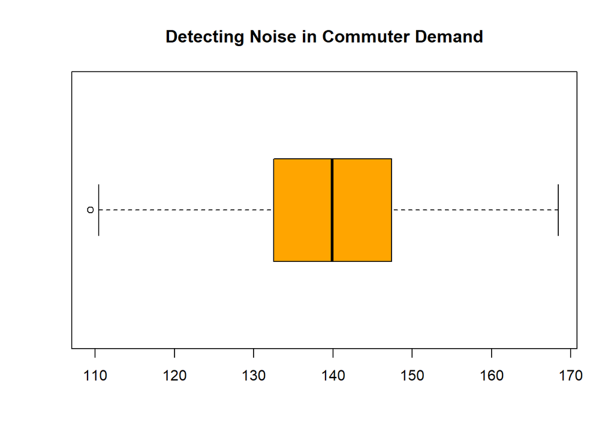

## Identifying Extreme Values To be more precise, we can use a statistical threshold. If a value is more than 3 standard deviations away from the mean, we classify it as an extreme outlier or ‘noise’.

```r
# Calculate mean and standard deviation
mean_val <- mean(data$CommuterDemand)
sd_val   <- sd(data$CommuterDemand)

# Identify rows that are more than 3 standard deviations from the mean
noise_rows <- which(abs(data$CommuterDemand - mean_val) > (3 * sd_val))

# Output the result
print(paste("Number of potential noise rows detected:", length(noise_rows)))
```

```
## [1] "Number of potential noise rows detected: 0"
```